# Model_jh4054

Joy Hsu

12/7/2018

### Load Main dataset

```r
cancer_reg = read_csv("./data/Cancer_Registry.csv") %>%
  janitor::clean_names() %>%
  dplyr::select(target_death_rate, everything()) %>%
  separate(geography, into = c("county", "state"), sep = ", ") %>%
  mutate(
    avg_deaths_per_year = as.numeric(avg_deaths_per_year),
    med_income = as.numeric(med_income),
    pop_est2015 = as.numeric(med_income),
    county = str_replace(county, " ", ""))
```

### 1. Remove Categorical and high proportion missing values

- Remove state and county - catergorical parameters related to observations
- Remove avg_ann_count and avg_deaths_per_year, since this data is already captured in mortality rate and incidence, weighted by county population.
- Remove variables with high percentage missing values:
  - pct_employed16_over - 152 missing. This variable has some collinearity with pct_unemployed16_over (R = -0.65), so we are not completely excluding information related to employment.
  - pct_some_col18_24 - 2285 missing. Over 2/3 missing values.
  - pct_private_coverage_alone - 609 missing. Since this variable has strong collinearity with pct_private_coverage (R = 0.93), so we are not excluding valuable information on insurance coverage

```r
# Examine missing values
# 3 variables with high missing: values pct_employed16_over (152), pct_some_col18_24 (2285), pct_private_coverage_alone (609)
skimr::skim(cancer_reg)
```

```
## Skim summary statistics
##  n obs: 3047
##  n variables: 35
##
## ── Variable type:character ─────────────────────────────────────────────────────
##    variable missing complete    n min max empty n_unique
##  binned_inc       0     3047 3047  16  18     0       10
##      county       0     3047 3047   9  30     0     1819
##       state       0     3047 3047   4  20     0       51
##
## ── Variable type:numeric ───────────────────────────────────────────────────────
##                    variable missing complete    n     mean       sd
##               avg_ann_count       0     3047 3047   606.34  1416.36
##         avg_deaths_per_year       0     3047 3047   185.97   504.13
##          avg_household_size       0     3047 3047     2.48     0.43
##                  birth_rate       0     3047 3047     5.64     1.99
##              incidence_rate       0     3047 3047   448.27    54.56
##                  med_income       0     3047 3047 47063.28 12040.09
##                  median_age       0     3047 3047    45.27    45.3
##           median_age_female       0     3047 3047    42.15     5.29
##             median_age_male       0     3047 3047    39.57     5.23
##                   pct_asian       0     3047 3047     1.25     2.61
##           pct_bach_deg18_24       0     3047 3047     6.16     4.53
##         pct_bach_deg25_over       0     3047 3047    13.28     5.39
##                   pct_black       0     3047 3047     9.11    14.53
##       pct_emp_priv_coverage       0     3047 3047    41.2      9.45
##         pct_employed16_over     152     2895 3047    54.15     8.32
##                 pct_hs18_24       0     3047 3047    35        9.07
##               pct_hs25_over       0     3047 3047    34.8      7.03
##      pct_married_households       0     3047 3047    51.24     6.57
##              pct_no_hs18_24       0     3047 3047    18.22     8.09
##              pct_other_race       0     3047 3047     1.98     3.52
##        pct_private_coverage       0     3047 3047    64.35    10.65
##  pct_private_coverage_alone     609     2438 3047    48.45    10.08
##         pct_public_coverage       0     3047 3047    36.25     7.84
##   pct_public_coverage_alone       0     3047 3047    19.24     6.11
##           pct_some_col18_24    2285      762 3047    40.98    11.12
##       pct_unemployed16_over       0     3047 3047     7.85     3.45
##                   pct_white       0     3047 3047    83.65    16.38
##             percent_married       0     3047 3047    51.77     6.9
```

[output cut: 22 more lines]

```
##     22.99     47.76    51.67    55.4      78.08 ▁▁▂▆▇▂▁▁
##      0        12.8     17.1     22.7      64.1  ▂▇▇▃▁▁▁▁
##      0         0.3      0.83     2.18     41.93 ▇▁▁▁▁▁▁▁
##     22.3      57.2     65.1     72.1      92.3  ▁▁▂▅▇▇▅▁
##     15.7      41       48.7     55.6      78.9  ▁▁▅▇▇▅▂▁
##     11.2      30.9     36.3     41.55     65.1  ▁▂▅▇▇▃▁▁
##      2.6      14.85    18.8     23.1      46.6  ▁▃▇▇▃▁▁▁
##      7.1      34       40.4     46.4      79    ▁▁▅▇▅▂▁▁
##      0.4       5.5      7.6      9.7      29.4  ▂▇▇▂▁▁▁▁
##     10.2      77.3     90.06    95.45    100    ▁▁▁▁▁▂▃▇
##     23.1      47.75    52.4     56.4      72.5  ▁▁▁▅▇▇▂▁
##  22640     38882.5  45207    52492    125635    ▂▇▅▁▁▁▁▁
##      3.2      12.15    15.9     20.4      47.4  ▂▇▇▅▂▁▁▁
##      0         0        0       83.65   9762.31 ▇▁▁▁▁▁▁▁
##     59.7     161.2    178.1    195.2     362.8  ▁▁▆▇▂▁▁▁
```

```r
# observe collinearity between pct_private_coverage and variable to exclude, pct_private_coverage_alone
cancer_reg %>%
  dplyr::select(target_death_rate, pct_private_coverage, pct_private_coverage_alone) %>% cor(x = ., use = "pairwise.complete.obs")
```

```
##                            target_death_rate pct_private_coverage
## target_death_rate                  1.0000000           -0.3860655
## pct_private_coverage              -0.3860655            1.0000000
## pct_private_coverage_alone        -0.3637037            0.9334958
##                            pct_private_coverage_alone
## target_death_rate                          -0.3637037
## pct_private_coverage                        0.9334958
## pct_private_coverage_alone                  1.0000000
```

```r
# observe collinearity between pct_unemployed16_over and variable to exclude, pct_employed16_over
cancer_reg %>%
  dplyr::select(target_death_rate, pct_unemployed16_over, pct_employed16_over) %>% cor(x = ., use = "pairwise.complete.obs")
```

```
##                       target_death_rate pct_unemployed16_over
## target_death_rate             1.0000000             0.3784124
## pct_unemployed16_over         0.3784124             1.0000000
## pct_employed16_over          -0.4120458            -0.6481142
##                       pct_employed16_over
## target_death_rate              -0.4120458
## pct_unemployed16_over          -0.6481142
## pct_employed16_over             1.0000000
```

```r
# remove variables with high missing values, county and state
cancer_reg_tidy = cancer_reg %>%
  dplyr::select(-pct_employed16_over, -pct_some_col18_24, -pct_private_coverage_alone, -county, -state, -avg_ann_count, -avg_deaths_per_year)
```

### 2. Remove Variables with high Collinearity

Next, we will examine collinearity between remaining variables. Remove the following:

Other variables of consideration. * pct_white and pct_black has high CL (-0.83), but from a demographic standpoint, we may be interested in keeping both. * create pct_nonwhite as a proxy * discuss why pct_black and pct_white has such negative correlation in report

We are left with 21 variables

```r
# Examine collinearity between variables
cor_df = cancer_reg_tidy %>%
  dplyr::select(-binned_inc) %>%
  cor()

# remove collinear variables
# remove variables due to missing values
# remove variables due to collinearity
# create proxy variable pct_nonwhite
cancer_reg_tidy = cancer_reg %>%
  dplyr::select(
    -pct_employed16_over, -pct_some_col18_24, -pct_private_coverage_alone, -county, -state,    -avg_ann_count, -avg_deaths_per_year) %>%
  dplyr::select(
    -med_income, -median_age_female, -pct_emp_priv_coverage, -pct_public_coverage, -pct_private_coverage, -pop_est2015, -poverty_percent, -pct_hs25_over) %>%
  mutate(pct_nonwhite = 1 - pct_white)
```

### 3. Variables to Transform IGNORE FOR NOW

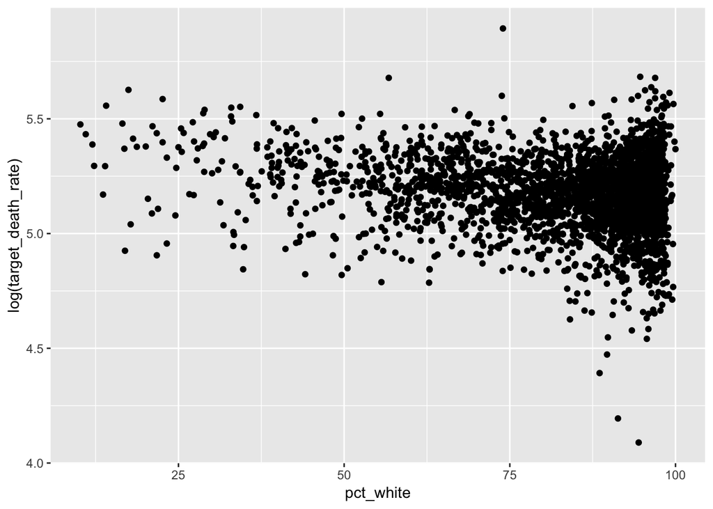

```r
# scatterplot b/w variables
cancer_reg %>%
  ggplot(aes(x = pct_white, y = log(target_death_rate))) +
  geom_point()
```

### 3. Automatic Search Procedures

Stepwise regression uses the AIC criterion for variable selection. Given a set of candidate models for the data, we prefer the model with the minimum AIC value. AIC rewards goodness of fit (as assessed by the likelihood function), but AIC also includes a penalty that is a function of number of parameters.

```r
# define full and null sets for forward, backward, both ways search procedures
null = lm(target_death_rate ~ 1, data = cancer_reg_tidy)

full = lm(target_death_rate ~ ., data = cancer_reg_tidy)
```

**Forward Selection Model**

Step: AIC=18101.67

12-Predictor Model(adj. R2: 0.5096): target_death_rate ~ pct_bach_deg25_over + incidence_rate + binned_inc + pct_married_households + pct_hs18_24 + pct_other_race + median_age_male + birth_rate + pct_public_coverage_alone + percent_married + pct_unemployed16_over + pct_white

```r
# stepwise regression, forward
step(null, scope = list(lower = null, upper = full), direction = "forward")
```

```
## Start:  AIC=20253.13
## target_death_rate ~ 1
##
##                             Df Sum of Sq     RSS   AIC
## + pct_bach_deg25_over        1    552893 1792973 19436
## + incidence_rate             1    473839 1872027 19568
## + pct_public_coverage_alone  1    473682 1872183 19568
## + binned_inc                 9    477496 1868370 19578
## + pct_unemployed16_over      1    335919 2009947 19784
## + pct_married_households     1    201838 2144028 19981
## + pct_bach_deg18_24          1    194329 2151537 19992
## + percent_married            1    167010 2178856 20030
## + pct_hs18_24                1    161000 2184866 20038
## + pct_black                  1    154971 2190895 20047
## + pct_other_race             1     84591 2261275 20143
## + pct_asian                  1     81447 2264419 20148
## + pct_white                  1     73826 2272040 20158
## + pct_nonwhite               1     73826 2272040 20158
## + pct_no_hs18_24             1     18358 2327508 20231
## + birth_rate                 1     17922 2327944 20232
## + avg_household_size         1      3195 2342671 20251
## <none>                                   2345866 20253
## + study_per_cap              1      1165 2344701 20254
## + median_age_male            1      1128 2344738 20254
## + median_age                 1        45 2345821 20255
##
## Step:  AIC=19436.16
## target_death_rate ~ pct_bach_deg25_over
##
##                             Df Sum of Sq     RSS   AIC
## + incidence_rate             1    436199 1356774 18589
## + pct_married_households     1    142974 1649999 19185
## + percent_married            1    111182 1681791 19243
## + pct_unemployed16_over      1    106117 1686856 19252
## + pct_public_coverage_alone  1     89344 1703629 19282
## + pct_black                  1     82887 1710086 19294
## + binned_inc                 9     89893 1703080 19297
## + pct_other_race             1     68639 1724334 19319
## + pct_white                  1     55608 1737365 19342
## + pct_nonwhite               1     55608 1737365 19342
```

[output cut: 219 more lines]

```
## Step:  AIC=18101.67
## target_death_rate ~ pct_bach_deg25_over + incidence_rate + binned_inc +
##     pct_married_households + pct_hs18_24 + pct_other_race + median_age_male +
##     birth_rate + pct_public_coverage_alone + percent_married +
##     pct_unemployed16_over + pct_white
##
##                      Df Sum of Sq     RSS   AIC
## <none>                            1142748 18102
## + pct_black           1    702.91 1142045 18102
## + pct_no_hs18_24      1    620.08 1142128 18102
## + avg_household_size  1    263.06 1142485 18103
## + median_age          1    131.86 1142616 18103
## + pct_bach_deg18_24   1     47.20 1142701 18104
## + pct_asian           1     38.41 1142710 18104
## + study_per_cap       1     28.02 1142720 18104
```

```
##
## Call:
## lm(formula = target_death_rate ~ pct_bach_deg25_over + incidence_rate +
##     binned_inc + pct_married_households + pct_hs18_24 + pct_other_race +
##     median_age_male + birth_rate + pct_public_coverage_alone +
##     percent_married + pct_unemployed16_over + pct_white, data = cancer_reg_tidy)
##
## Coefficients:
##                  (Intercept)           pct_bach_deg25_over
##                     144.6046                       -1.6280
##               incidence_rate  binned_inc(37413.8, 40362.7]
##                       0.1952                       -1.9570
## binned_inc(40362.7, 42724.4]    binned_inc(42724.4, 45201]
##                      -4.1568                       -4.8967
##   binned_inc(45201, 48021.6]  binned_inc(48021.6, 51046.4]
##                      -6.4616                       -9.0508
## binned_inc(51046.4, 54545.6]  binned_inc(54545.6, 61494.5]
##                      -8.3254                       -7.0661
##  binned_inc(61494.5, 125635]    binned_inc[22640, 34218.1]
##                      -4.7259                        3.6222
##       pct_married_households                   pct_hs18_24
##                      -0.7810                        0.3502
##               pct_other_race               median_age_male
##                      -0.9697                       -0.7168
##                   birth_rate     pct_public_coverage_alone
##                      -1.0544                        0.3608
##              percent_married         pct_unemployed16_over
##                       0.5941                        0.3639
##                    pct_white
##                      -0.0486
```

```r
# forward fit
fit_forward = lm(target_death_rate ~ pct_bach_deg25_over + incidence_rate + binned_inc +
    pct_married_households + pct_hs18_24 + pct_other_race + median_age_male +
    birth_rate + pct_public_coverage_alone + percent_married +
    pct_unemployed16_over + pct_white, data = cancer_reg_tidy)

summary(fit_forward)
```

```
##
## Call:
## lm(formula = target_death_rate ~ pct_bach_deg25_over + incidence_rate +
##     binned_inc + pct_married_households + pct_hs18_24 + pct_other_race +
##     median_age_male + birth_rate + pct_public_coverage_alone +
##     percent_married + pct_unemployed16_over + pct_white, data = cancer_reg_tidy)
##
## Residuals:
##      Min       1Q   Median       3Q      Max
## -102.125  -11.068    0.139   10.999  135.432
##
## Coefficients:
##                                Estimate Std. Error t value Pr(>|t|)
## (Intercept)                  144.604551   7.107004  20.347  < 2e-16 ***
## pct_bach_deg25_over           -1.628018   0.105437 -15.441  < 2e-16 ***
## incidence_rate                 0.195173   0.006882  28.359  < 2e-16 ***
## binned_inc(37413.8, 40362.7]  -1.956997   1.597238  -1.225 0.220581
## binned_inc(40362.7, 42724.4]  -4.156849   1.623277  -2.561 0.010492 *
## binned_inc(42724.4, 45201]    -4.896660   1.667387  -2.937 0.003342 **
## binned_inc(45201, 48021.6]    -6.461571   1.709893  -3.779 0.000161 ***
## binned_inc(48021.6, 51046.4]  -9.050800   1.768071  -5.119 3.26e-07 ***
## binned_inc(51046.4, 54545.6]  -8.325418   1.841828  -4.520 6.42e-06 ***
## binned_inc(54545.6, 61494.5]  -7.066072   1.932782  -3.656 0.000261 ***
## binned_inc(61494.5, 125635]   -4.725916   2.277365  -2.075 0.038055 *
## binned_inc[22640, 34218.1]     3.622218   1.633893   2.217 0.026702 *
## pct_married_households        -0.780961   0.129910  -6.012 2.06e-09 ***
## pct_hs18_24                    0.350153   0.044699   7.834 6.51e-15 ***
## pct_other_race                -0.969706   0.111437  -8.702  < 2e-16 ***
## median_age_male               -0.716806   0.091188  -7.861 5.26e-15 ***
## birth_rate                    -1.054444   0.189493  -5.565 2.86e-08 ***
## pct_public_coverage_alone      0.360836   0.107841   3.346 0.000830 ***
## percent_married                0.594113   0.138425   4.292 1.83e-05 ***
## pct_unemployed16_over          0.363874   0.153498   2.371 0.017824 *
## pct_white                     -0.048597   0.032635  -1.489 0.136562
## ---
## Signif. codes:  0 '***' 0.001 '**' 0.01 '*' 0.05 '.' 0.1 ' ' 1
##
## Residual standard error: 19.43 on 3026 degrees of freedom
## Multiple R-squared:  0.5129, Adjusted R-squared:  0.5096
## F-statistic: 159.3 on 20 and 3026 DF,  p-value: < 2.2e-16
```

**Backward Elimination Model**

Step: AIC=18101.67

12-predictor Model (Adjusted R-squared: 0.5096) :target_death_rate ~ incidence_rate + binned_inc + median_age_male + percent_married + pct_hs18_24 + pct_bach_deg25_over + pct_unemployed16_over + pct_public_coverage_alone + pct_white + pct_other_race + pct_married_households + birth_rate

```r
# stepwise regression, backward
step(full, data = cancer_reg_tidy, direction="backward")
```

```
## Start:  AIC=18109.8
## target_death_rate ~ incidence_rate + study_per_cap + binned_inc +
##     median_age + median_age_male + avg_household_size + percent_married +
##     pct_no_hs18_24 + pct_hs18_24 + pct_bach_deg18_24 + pct_bach_deg25_over +
##     pct_unemployed16_over + pct_public_coverage_alone + pct_white +
##     pct_black + pct_asian + pct_other_race + pct_married_households +
##     birth_rate + pct_nonwhite
##
##
## Step:  AIC=18109.8
## target_death_rate ~ incidence_rate + study_per_cap + binned_inc +
##     median_age + median_age_male + avg_household_size + percent_married +
##     pct_no_hs18_24 + pct_hs18_24 + pct_bach_deg18_24 + pct_bach_deg25_over +
##     pct_unemployed16_over + pct_public_coverage_alone + pct_white +
##     pct_black + pct_asian + pct_other_race + pct_married_households +
##     birth_rate
##
##                             Df Sum of Sq     RSS   AIC
## - study_per_cap              1        34 1140584 18108
## - pct_bach_deg18_24          1        98 1140648 18108
## - median_age                 1       153 1140702 18108
## - avg_household_size         1       193 1140742 18108
## - pct_asian                  1       304 1140854 18109
## <none>                                   1140549 18110
## - pct_black                  1       895 1141444 18110
## - pct_no_hs18_24             1       907 1141457 18110
## - pct_unemployed16_over      1      1906 1142455 18113
## - pct_white                  1      1923 1142473 18113
## - pct_public_coverage_alone  1      3517 1144066 18117
## - percent_married            1      6660 1147209 18126
## - birth_rate                 1     11841 1152390 18139
## - pct_married_households     1     12793 1153343 18142
## - binned_inc                 9     23675 1164224 18154
## - median_age_male            1     18106 1158656 18156
## - pct_hs18_24                1     18675 1159224 18157
## - pct_other_race             1     27650 1168200 18181
## - pct_bach_deg25_over        1     79272 1219821 18312
## - incidence_rate             1    294111 1434661 18807
##
## Step:  AIC=18107.9
```

[output cut: 156 more lines]

```
##
##                             Df Sum of Sq     RSS   AIC
## <none>                                   1142748 18102
## - pct_white                  1       837 1143586 18102
## - pct_unemployed16_over      1      2122 1144870 18105
## - pct_public_coverage_alone  1      4228 1146976 18111
## - percent_married            1      6957 1149705 18118
## - birth_rate                 1     11693 1154442 18131
## - pct_married_households     1     13648 1156396 18136
## - binned_inc                 9     22639 1165387 18143
## - pct_hs18_24                1     23174 1165922 18161
## - median_age_male            1     23335 1166084 18161
## - pct_other_race             1     28596 1171344 18175
## - pct_bach_deg25_over        1     90035 1232783 18331
## - incidence_rate             1    303713 1446461 18818
```

```
##
## Call:
## lm(formula = target_death_rate ~ incidence_rate + binned_inc +
##     median_age_male + percent_married + pct_hs18_24 + pct_bach_deg25_over +
##     pct_unemployed16_over + pct_public_coverage_alone + pct_white +
##     pct_other_race + pct_married_households + birth_rate, data = cancer_reg_tidy)
##
## Coefficients:
##                  (Intercept)                incidence_rate
##                     144.6046                        0.1952
## binned_inc(37413.8, 40362.7]  binned_inc(40362.7, 42724.4]
##                      -1.9570                       -4.1568
##   binned_inc(42724.4, 45201]    binned_inc(45201, 48021.6]
##                      -4.8967                       -6.4616
## binned_inc(48021.6, 51046.4]  binned_inc(51046.4, 54545.6]
##                      -9.0508                       -8.3254
## binned_inc(54545.6, 61494.5]   binned_inc(61494.5, 125635]
##                      -7.0661                       -4.7259
##   binned_inc[22640, 34218.1]               median_age_male
##                       3.6222                       -0.7168
##              percent_married                   pct_hs18_24
##                       0.5941                        0.3502
##          pct_bach_deg25_over         pct_unemployed16_over
##                      -1.6280                        0.3639
##    pct_public_coverage_alone                     pct_white
##                       0.3608                       -0.0486
##               pct_other_race        pct_married_households
##                      -0.9697                       -0.7810
##                   birth_rate
##                      -1.0544
```

```r
# backward fit
fit_back = lm(target_death_rate ~ incidence_rate + binned_inc + median_age_male +
    percent_married + pct_hs18_24 + pct_bach_deg25_over + pct_unemployed16_over +
    pct_public_coverage_alone + pct_white + pct_other_race +
    pct_married_households + birth_rate, data = cancer_reg_tidy)

summary(fit_back)
```

```
##
## Call:
## lm(formula = target_death_rate ~ incidence_rate + binned_inc +
##     median_age_male + percent_married + pct_hs18_24 + pct_bach_deg25_over +
##     pct_unemployed16_over + pct_public_coverage_alone + pct_white +
##     pct_other_race + pct_married_households + birth_rate, data = cancer_reg_tidy)
##
## Residuals:
##      Min       1Q   Median       3Q      Max
## -102.125  -11.068    0.139   10.999  135.432
##
## Coefficients:
##                                Estimate Std. Error t value Pr(>|t|)
## (Intercept)                  144.604551   7.107004  20.347  < 2e-16 ***
## incidence_rate                 0.195173   0.006882  28.359  < 2e-16 ***
## binned_inc(37413.8, 40362.7]  -1.956997   1.597238  -1.225 0.220581
## binned_inc(40362.7, 42724.4]  -4.156849   1.623277  -2.561 0.010492 *
## binned_inc(42724.4, 45201]    -4.896660   1.667387  -2.937 0.003342 **
## binned_inc(45201, 48021.6]    -6.461571   1.709893  -3.779 0.000161 ***
## binned_inc(48021.6, 51046.4]  -9.050800   1.768071  -5.119 3.26e-07 ***
## binned_inc(51046.4, 54545.6]  -8.325418   1.841828  -4.520 6.42e-06 ***
## binned_inc(54545.6, 61494.5]  -7.066072   1.932782  -3.656 0.000261 ***
## binned_inc(61494.5, 125635]   -4.725916   2.277365  -2.075 0.038055 *
## binned_inc[22640, 34218.1]     3.622218   1.633893   2.217 0.026702 *
## median_age_male               -0.716806   0.091188  -7.861 5.26e-15 ***
## percent_married                0.594113   0.138425   4.292 1.83e-05 ***
## pct_hs18_24                    0.350153   0.044699   7.834 6.51e-15 ***
## pct_bach_deg25_over           -1.628018   0.105437 -15.441  < 2e-16 ***
## pct_unemployed16_over          0.363874   0.153498   2.371 0.017824 *
## pct_public_coverage_alone      0.360836   0.107841   3.346 0.000830 ***
## pct_white                     -0.048597   0.032635  -1.489 0.136562
## pct_other_race                -0.969706   0.111437  -8.702  < 2e-16 ***
## pct_married_households        -0.780961   0.129910  -6.012 2.06e-09 ***
## birth_rate                    -1.054444   0.189493  -5.565 2.86e-08 ***
## ---
## Signif. codes:  0 '***' 0.001 '**' 0.01 '*' 0.05 '.' 0.1 ' ' 1
##
## Residual standard error: 19.43 on 3026 degrees of freedom
## Multiple R-squared:  0.5129, Adjusted R-squared:  0.5096
## F-statistic: 159.3 on 20 and 3026 DF,  p-value: < 2.2e-16
```

**Stepwise Regression, Both Directions**

Same output as others

Step: AIC=18101.67

12-predictor Model (Adjusted R-squared: 0.5096): target_death_rate ~ pct_bach_deg25_over + incidence_rate + binned_inc + pct_married_households + pct_hs18_24 + pct_other_race + median_age_male + birth_rate + pct_public_coverage_alone + percent_married + pct_unemployed16_over + pct_white

```r
# stepwise regression, both directions
step(null, scope = list(upper=full), data = cancer_reg_tidy, direction="both")
```

```
## Start:  AIC=20253.13
## target_death_rate ~ 1
##
##                             Df Sum of Sq     RSS   AIC
## + pct_bach_deg25_over        1    552893 1792973 19436
## + incidence_rate             1    473839 1872027 19568
## + pct_public_coverage_alone  1    473682 1872183 19568
## + binned_inc                 9    477496 1868370 19578
## + pct_unemployed16_over      1    335919 2009947 19784
## + pct_married_households     1    201838 2144028 19981
## + pct_bach_deg18_24          1    194329 2151537 19992
## + percent_married            1    167010 2178856 20030
## + pct_hs18_24                1    161000 2184866 20038
## + pct_black                  1    154971 2190895 20047
## + pct_other_race             1     84591 2261275 20143
## + pct_asian                  1     81447 2264419 20148
## + pct_white                  1     73826 2272040 20158
## + pct_nonwhite               1     73826 2272040 20158
## + pct_no_hs18_24             1     18358 2327508 20231
## + birth_rate                 1     17922 2327944 20232
## + avg_household_size         1      3195 2342671 20251
## <none>                                   2345866 20253
## + study_per_cap              1      1165 2344701 20254
## + median_age_male            1      1128 2344738 20254
## + median_age                 1        45 2345821 20255
##
## Step:  AIC=19436.16
## target_death_rate ~ pct_bach_deg25_over
##
##                             Df Sum of Sq     RSS   AIC
## + incidence_rate             1    436199 1356774 18589
## + pct_married_households     1    142974 1649999 19185
## + percent_married            1    111182 1681791 19243
## + pct_unemployed16_over      1    106117 1686856 19252
## + pct_public_coverage_alone  1     89344 1703629 19282
## + pct_black                  1     82887 1710086 19294
## + binned_inc                 9     89893 1703080 19297
## + pct_other_race             1     68639 1724334 19319
## + pct_white                  1     55608 1737365 19342
## + pct_nonwhite               1     55608 1737365 19342
```

[output cut: 297 more lines]

```
## + median_age                 1       132 1142616 18103
## + pct_bach_deg18_24          1        47 1142701 18104
## + pct_asian                  1        38 1142710 18104
## + study_per_cap              1        28 1142720 18104
## - pct_unemployed16_over      1      2122 1144870 18105
## - pct_public_coverage_alone  1      4228 1146976 18111
## - percent_married            1      6957 1149705 18118
## - birth_rate                 1     11693 1154442 18131
## - pct_married_households     1     13648 1156396 18136
## - binned_inc                 9     22639 1165387 18143
## - pct_hs18_24                1     23174 1165922 18161
## - median_age_male            1     23335 1166084 18161
## - pct_other_race             1     28596 1171344 18175
## - pct_bach_deg25_over        1     90035 1232783 18331
## - incidence_rate             1    303713 1446461 18818
```

```
##
## Call:
## lm(formula = target_death_rate ~ pct_bach_deg25_over + incidence_rate +
##     binned_inc + pct_married_households + pct_hs18_24 + pct_other_race +
##     median_age_male + birth_rate + pct_public_coverage_alone +
##     percent_married + pct_unemployed16_over + pct_white, data = cancer_reg_tidy)
##
## Coefficients:
##                  (Intercept)           pct_bach_deg25_over
##                     144.6046                       -1.6280
##               incidence_rate  binned_inc(37413.8, 40362.7]
##                       0.1952                       -1.9570
## binned_inc(40362.7, 42724.4]    binned_inc(42724.4, 45201]
##                      -4.1568                       -4.8967
##   binned_inc(45201, 48021.6]  binned_inc(48021.6, 51046.4]
##                      -6.4616                       -9.0508
## binned_inc(51046.4, 54545.6]  binned_inc(54545.6, 61494.5]
##                      -8.3254                       -7.0661
##  binned_inc(61494.5, 125635]    binned_inc[22640, 34218.1]
##                      -4.7259                        3.6222
##       pct_married_households                   pct_hs18_24
##                      -0.7810                        0.3502
##               pct_other_race               median_age_male
##                      -0.9697                       -0.7168
##                   birth_rate     pct_public_coverage_alone
##                      -1.0544                        0.3608
##              percent_married         pct_unemployed16_over
##                       0.5941                        0.3639
##                    pct_white
##                      -0.0486
```

```r
fit_both_dir = lm(target_death_rate ~ pct_bach_deg25_over + incidence_rate + binned_inc + pct_married_households + pct_hs18_24 + pct_other_race + median_age_male +
    birth_rate + pct_public_coverage_alone + percent_married +
    pct_unemployed16_over + pct_white, data = cancer_reg_tidy)

summary(fit_both_dir)
```

```
##
## Call:
## lm(formula = target_death_rate ~ pct_bach_deg25_over + incidence_rate +
##     binned_inc + pct_married_households + pct_hs18_24 + pct_other_race +
##     median_age_male + birth_rate + pct_public_coverage_alone +
##     percent_married + pct_unemployed16_over + pct_white, data = cancer_reg_tidy)
##
## Residuals:
##      Min       1Q   Median       3Q      Max
## -102.125  -11.068    0.139   10.999  135.432
##
## Coefficients:
##                                Estimate Std. Error t value Pr(>|t|)
## (Intercept)                  144.604551   7.107004  20.347  < 2e-16 ***
## pct_bach_deg25_over           -1.628018   0.105437 -15.441  < 2e-16 ***
## incidence_rate                 0.195173   0.006882  28.359  < 2e-16 ***
## binned_inc(37413.8, 40362.7]  -1.956997   1.597238  -1.225 0.220581
## binned_inc(40362.7, 42724.4]  -4.156849   1.623277  -2.561 0.010492 *
## binned_inc(42724.4, 45201]    -4.896660   1.667387  -2.937 0.003342 **
## binned_inc(45201, 48021.6]    -6.461571   1.709893  -3.779 0.000161 ***
## binned_inc(48021.6, 51046.4]  -9.050800   1.768071  -5.119 3.26e-07 ***
## binned_inc(51046.4, 54545.6]  -8.325418   1.841828  -4.520 6.42e-06 ***
## binned_inc(54545.6, 61494.5]  -7.066072   1.932782  -3.656 0.000261 ***
## binned_inc(61494.5, 125635]   -4.725916   2.277365  -2.075 0.038055 *
## binned_inc[22640, 34218.1]     3.622218   1.633893   2.217 0.026702 *
## pct_married_households        -0.780961   0.129910  -6.012 2.06e-09 ***
## pct_hs18_24                    0.350153   0.044699   7.834 6.51e-15 ***
## pct_other_race                -0.969706   0.111437  -8.702  < 2e-16 ***
## median_age_male               -0.716806   0.091188  -7.861 5.26e-15 ***
## birth_rate                    -1.054444   0.189493  -5.565 2.86e-08 ***
## pct_public_coverage_alone      0.360836   0.107841   3.346 0.000830 ***
## percent_married                0.594113   0.138425   4.292 1.83e-05 ***
## pct_unemployed16_over          0.363874   0.153498   2.371 0.017824 *
## pct_white                     -0.048597   0.032635  -1.489 0.136562
## ---
## Signif. codes:  0 '***' 0.001 '**' 0.01 '*' 0.05 '.' 0.1 ' ' 1
##
## Residual standard error: 19.43 on 3026 degrees of freedom
## Multiple R-squared:  0.5129, Adjusted R-squared:  0.5096
## F-statistic: 159.3 on 20 and 3026 DF,  p-value: < 2.2e-16
```

**Conclusion**

Automatic Search Procedures using forward & backward selection, stepwise regression generated the same “best model” with 12-parameters, using the AIC criterion. The model has Adjusted R-squared: 0.5096.

### 4. Criterion Based Procedures

**Best subsets regression procedure with Mallows’ Cp and Adjusted R2 Criterion**

- For Mallow’s Cp-statistic, the Cp Statistic should be less than or equal to the # of parameters. Optimizing for lowest Cp Statistic, we select 15 parameters.
- For R^2(adj) criteria, we optimize for highest R^2(adj), while accounting for parsimony. Selecting ~10 parameters optimizes both the R^2(adj) criterion and overarching goal for parsimony. Not much improvement over 10 parameters.
- We should have a 10 parameter and 15 parameter model.

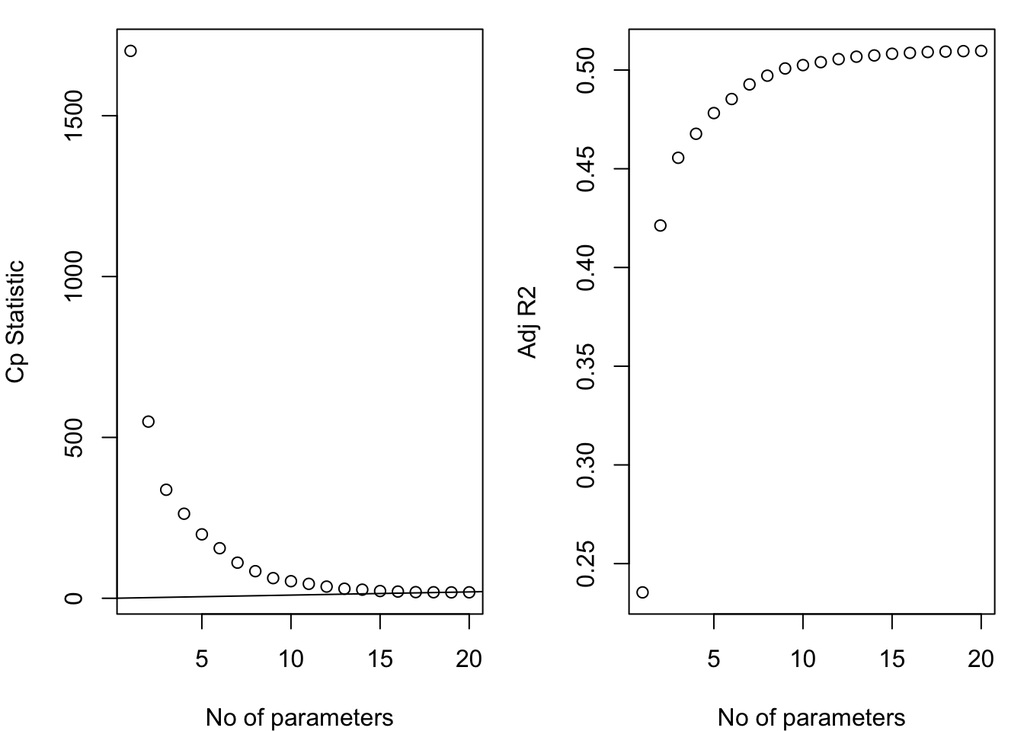

```r
criterion = leaps::regsubsets(target_death_rate ~ ., data = cancer_reg_tidy, nvmax = 20)
crit_sum = summary(criterion)

# Plots for Cp Statistic and Adjusted R2
par(mar = c(4,4,1,1))
par(mfrow = c(1,2))

# Cp Statistic Plot
plot(x = 1:20, y = crit_sum$cp, xlab = "No of parameters", ylab = "Cp Statistic")
# abline - adds straight lines to a plot
abline(0,1)

# Adjusted R2 Plot
plot(x = 1:20, y = crit_sum$adjr2, xlab = "No of parameters", ylab = "Adj R2")
```

**Summary Table for Cp Statistic and Adjusted R2**

```r
# fit with all parameters
fit_multi = lm(target_death_rate ~ ., data = cancer_reg_tidy)

# best subset of variables for given number of parameters
best = function(model, ...)
{
  subsets <- regsubsets(formula(model), nvmax = 21, model.frame(model), ...)
  subsets <- with(summary(subsets),
                  cbind(p = as.numeric(rownames(which)), which, rss, rsq, adjr2, cp, bic))

  return(subsets)
}

# Select the 'best' model of all subsets for 8-predictor model
cp_r2_df = round(best(fit_multi, nbest = 1), digits = 4)

cp_r2_df
```

```
##     p (Intercept) incidence_rate study_per_cap
## 1   1           1              0             0
## 2   2           1              1             0
## 3   3           1              1             0
## 4   4           1              1             0
## 5   5           1              1             0
## 6   6           1              1             0
## 7   7           1              1             0
## 8   8           1              1             0
## 9   9           1              1             0
## 10 10           1              1             0
## 11 11           1              1             0
## 12 12           1              1             0
## 13 13           1              1             0
## 14 14           1              1             0
```

[output cut: 227 more lines]

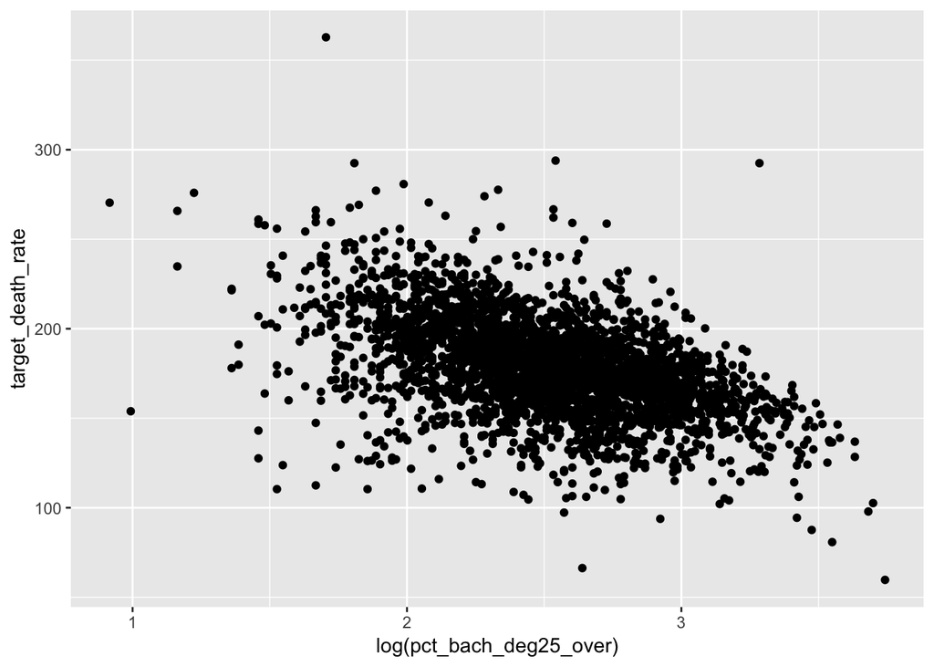

```r
# should take log for pct_bach_deg25_over variable
cancer_reg_tidy %>%
  ggplot(aes(x = log(pct_bach_deg25_over), y = target_death_rate)) +
  geom_point()
```

### 5. Final Model Recommend

**12-predictor Model (Adjusted R-squared: 0.5096):** target_death_rate ~ pct_bach_deg25_over + incidence_rate + binned_inc + pct_married_households + pct_hs18_24 + pct_other_race + median_age_male + birth_rate + pct_public_coverage_alone + percent_married + pct_unemployed16_over + pct_white

```r
fit_final = lm(target_death_rate ~ pct_bach_deg25_over + incidence_rate + binned_inc + pct_married_households + pct_hs18_24 + pct_other_race + median_age_male + birth_rate + pct_public_coverage_alone + percent_married + pct_unemployed16_over + pct_white, data = cancer_reg_tidy)

summary(fit_final)
```

```
##
## Call:
## lm(formula = target_death_rate ~ pct_bach_deg25_over + incidence_rate +
##     binned_inc + pct_married_households + pct_hs18_24 + pct_other_race +
##     median_age_male + birth_rate + pct_public_coverage_alone +
##     percent_married + pct_unemployed16_over + pct_white, data = cancer_reg_tidy)
##
## Residuals:
##      Min       1Q   Median       3Q      Max
## -102.125  -11.068    0.139   10.999  135.432
##
## Coefficients:
##                                Estimate Std. Error t value Pr(>|t|)
## (Intercept)                  144.604551   7.107004  20.347  < 2e-16 ***
## pct_bach_deg25_over           -1.628018   0.105437 -15.441  < 2e-16 ***
## incidence_rate                 0.195173   0.006882  28.359  < 2e-16 ***
## binned_inc(37413.8, 40362.7]  -1.956997   1.597238  -1.225 0.220581
## binned_inc(40362.7, 42724.4]  -4.156849   1.623277  -2.561 0.010492 *
## binned_inc(42724.4, 45201]    -4.896660   1.667387  -2.937 0.003342 **
## binned_inc(45201, 48021.6]    -6.461571   1.709893  -3.779 0.000161 ***
## binned_inc(48021.6, 51046.4]  -9.050800   1.768071  -5.119 3.26e-07 ***
## binned_inc(51046.4, 54545.6]  -8.325418   1.841828  -4.520 6.42e-06 ***
## binned_inc(54545.6, 61494.5]  -7.066072   1.932782  -3.656 0.000261 ***
## binned_inc(61494.5, 125635]   -4.725916   2.277365  -2.075 0.038055 *
## binned_inc[22640, 34218.1]     3.622218   1.633893   2.217 0.026702 *
## pct_married_households        -0.780961   0.129910  -6.012 2.06e-09 ***
## pct_hs18_24                    0.350153   0.044699   7.834 6.51e-15 ***
## pct_other_race                -0.969706   0.111437  -8.702  < 2e-16 ***
## median_age_male               -0.716806   0.091188  -7.861 5.26e-15 ***
## birth_rate                    -1.054444   0.189493  -5.565 2.86e-08 ***
## pct_public_coverage_alone      0.360836   0.107841   3.346 0.000830 ***
## percent_married                0.594113   0.138425   4.292 1.83e-05 ***
## pct_unemployed16_over          0.363874   0.153498   2.371 0.017824 *
## pct_white                     -0.048597   0.032635  -1.489 0.136562
## ---
## Signif. codes:  0 '***' 0.001 '**' 0.01 '*' 0.05 '.' 0.1 ' ' 1
##
## Residual standard error: 19.43 on 3026 degrees of freedom
## Multiple R-squared:  0.5129, Adjusted R-squared:  0.5096
## F-statistic: 159.3 on 20 and 3026 DF,  p-value: < 2.2e-16
```